# KUO_CHIHYU_A1

**A1: Unsupervised Analysis Project**

Chih-Yu Kuo  
Hult International Business School  
Master of Business Analytics (2023-2024) - San Francisco

**DAT-5329 - FMBAN1 | Introduction to Machine Learning & AI**  
Professor Chase Kusterer

April 14th, 2024

# Question 1: Introduction

In Thailand, the vibrant market of social media presents a unique landscape for marketing, particularly within the growing landscape of Facebook Live Selling. As a nation that embraces digital interaction, understanding user engagement on platforms such as Facebook is crucial for tailoring content strategies that engage with the audience. This analysis will evaluate the belief that photos are the ideal medium for maximizing user engagement on social media. By looking at the different metrics, the study aims to empirically assess the impact of photo content relative to other content types. Therefore, this analysis will use advanced analytical techniques such as principal component analysis (PCA), logistic regression, and k-means clustering to provide an understanding of content performance. The outcomes of this analysis will serve as a scope for strategic content planning, steering marketing efforts towards data-driven decisions in the dynamic landscape of Thai social media commerce.

```python
########################################
# importing packages
########################################
import numpy                 as np  # mathematical essentials
import pandas                as pd  # data science essentials
import matplotlib.pyplot     as plt # fundamental data visualization
import seaborn               as sns # enhanced visualizations

# packages for unsupervised learning
from sklearn.preprocessing   import StandardScaler      # standard scaler
from sklearn.decomposition   import PCA                 # principal component analysis
from sklearn.cluster import KMeans                      # k-means clustering
import statsmodels.formula.api as smf                   # statistical modeling and formula API
from sklearn.model_selection import train_test_split    # splitting data into train and test sets
from sklearn.metrics import confusion_matrix            # confusion matrix for classification evaluation
from scipy.cluster.hierarchy import dendrogram, linkage # dendrograms
from sklearn.linear_model import LogisticRegression     # logistic regression
from sklearn.metrics import accuracy_score              # accuracy score
```

```python
########################################
# loading data and setting display options
########################################
# loading data
facebook_df = pd.read_excel('facebook_live_data.xlsx')

# setting print options
pd.set_option('display.max_rows', 500)
pd.set_option('display.max_columns', 500)
pd.set_option('display.width', 1000)
pd.set_option('display.max_colwidth', 100)

# checking results
facebook_df.head(n = 10)
```

|  | status_id | status_type | time_published | num_comments | num_shares | num_likes | num_loves | num_wows | num_hahas | num_sads | num_angrys |
| --- | --- | --- | --- | --- | --- | --- | --- | --- | --- | --- | --- |
| 0 | 1 | photo | 2023-07-04 22:45:00 | 0 | 0 | 150 | 0 | 0 | 0 | 0 | 0 |
| 1 | 2 | photo | 2023-06-23 01:01:00 | 2 | 3 | 202 | 7 | 1 | 0 | 0 | 0 |
| 2 | 3 | photo | 2023-06-21 02:23:00 | 4 | 0 | 200 | 8 | 1 | 0 | 0 | 0 |
| 3 | 4 | video | 2023-06-14 05:16:00 | 100 | 30 | 303 | 23 | 1 | 5 | 0 | 0 |
| 4 | 5 | video | 2023-06-08 08:28:00 | 173 | 47 | 132 | 16 | 1 | 0 | 1 | 0 |
| 5 | 6 | photo | 2023-06-03 08:40:00 | 15 | 1 | 221 | 12 | 1 | 0 | 0 | 0 |
| 6 | 7 | video | 2023-06-01 22:34:00 | 0 | 1 | 37 | 0 | 0 | 0 | 0 | 0 |
| 7 | 8 | photo | 2023-05-22 05:55:00 | 0 | 0 | 81 | 2 | 2 | 0 | 0 | 0 |
| 8 | 9 | photo | 2023-05-18 02:48:00 | 8 | 0 | 281 | 11 | 1 | 0 | 0 | 0 |
| 9 | 10 | photo | 2023-05-13 01:43:00 | 11 | 6 | 61 | 4 | 1 | 0 | 0 | 0 |

```python
# Group by 'status_type' and calculate the sum of reactions for each type
grouped_reactions = facebook_df.groupby('status_type')[[
                    'num_comments',
                    'num_shares',
                    'num_likes',
                    'num_loves',
                    'num_wows',
                    'num_hahas',
                    'num_sads',
                    'num_angrys']].sum()

# Calculate total engagement for each content type
grouped_reactions['total_engagement'] = grouped_reactions.sum(axis=1)

# Count the number of each content type
content_counts = facebook_df['status_type'].value_counts()

# Calculate average engagement per post for each content type
average_engagement = grouped_reactions['total_engagement'] / content_counts

# Display the results
print("Average engagement per content type:\n", average_engagement)
print("\nTotal engagement per content type:\n", grouped_reactions['total_engagement'])
print("\nSpecific reactions per content type:\n", grouped_reactions)
```

```
Average engagement per content type:
 photo     202.936937
text      511.012821
video    1090.307995
dtype: float64

Total engagement per content type:
 status_type
photo    292838
text      79718
video    831905
Name: total_engagement, dtype: int64

Specific reactions per content type:
              num_comments  num_shares  num_likes  num_loves  num_wows  num_hahas  num_sads  num_angrys  total_engagement
status_type
photo               31796        4385     253180       2009       983        168       239          78            292838
text                 5898         517      72918        189       134         20        40           2             79718
video              514376       89158     196253      28100      1912       1560       336         210            831905
```

# Question 2:

In terms of reactions, how do photos perform when compared to other forms of content? Are they leading in terms of total engagement? What about in engagement on specific reactions?

## Average engagement per content type

Photos have an average engagement of about 202.9 per post, text posts have an average engagement of 511.0 per post, and video posts lead with the highest average engagement at 1,090.3 per post.

## Total engagement per content type

Looking at the total engagement per content type, videos are leading, not photos. Photos received a total engagement of 292,838, while text content is significantly lower at 79,718 with videos leading with a total engagement at 831,905.

## Engagement on specific reactions

When it comes to the number of comments, video had the highest of comments at 514376, followed by photos at 31796, while text had the lowest number of comments at 5898.

When it comes to the number of shares, video had the highest number of shares at 89158, followed by photos at 4385, while text had the lowest number of shares at 517.

When it comes to the number of likes, photos had the highest number of likes at 253180, followed by videos at 196253, while text had the lowest number of likes at 72918.

When it comes to the number of loves, video had the highest number of loves at 28100, followed by photo at 2009, while text had the lowest number of loves at 189.

When it comes to the number of wows, video had the highest number of wows at 1912, followed by photo at 983, while text had the lowest number of wows at 134.

When it comes to the number of hahas, video had the highest number of hahas at 1560, followed by photo at 168, while text had the lowest number of hahas at 20.

When it comes to the number of sads, video had the highest number of sads at 336, followed by photo at 239, while text had the lowest number of sads at 40.

When it comes to the number of angrys, video had the highest number of angrys at 210, followed by photo at 78, while text had the lowest number of angrys at 2.

## Conclusion

Videos seem to be the leading content type in terms of total and average engagement, particularly driven by a high number of comments, which suggests a higher level of interaction and possibly longer viewing time or discussion. Moreover, photos, while not reaching the engagement levels of videos, still show strong performance, especially in likes, indicating that they are well-received content for quick consumption and appreciation. However, text content has the least total engagement but a higher than expected average engagement per post.

# Question 3: Principal Components (PCA)

## Performing PCA

```python
# scree_plot

def scree_plot(pca_object, export = False):
    # building a scree plot

    # setting plot size
    fig, ax = plt.subplots(figsize=(10, 8))
    features = range(pca_object.n_components_)

    # developing a scree plot
    plt.plot(features,
             pca_object.explained_variance_ratio_,
             linewidth = 2,             # sets the width of the lines
             marker = 'o',              # sets the style of the markers
             markersize = 10,           # sets the size of the markers
             markeredgecolor = 'black', # sets the color of the marker borders
             markerfacecolor = 'grey')  # sets the fill color of the markers

    # setting more plot options
    plt.title('Scree Plot')             # sets the title of the plot
    plt.xlabel('PCA feature')           # sets the label for the x-axis
    plt.ylabel('Explained Variance')    # sets the label for the y-axis

    # Example cutoff at the 4th component (which is index 3)
    plt.axvline(x=3, linestyle=':', color='red') # adds a vertical dotted line at x=3 with red color

    plt.xticks(features) # Setting the ticks for the x-axis based on the number of features

    # forcing the plot to display the vertical line
    plt.draw()

    # displaying the plot
    plt.show()


########################################
# unsupervised_scaler
########################################
def scaler(df):
    """
    Standardizes a dataset (mean = 0, variance = 1). Returns a new DataFrame.
    Requires sklearn.preprocessing.StandardScaler()

    PARAMETERS
    ----------
    df     | DataFrame to be used for scaling
    """

    # INSTANTIATING a StandardScaler() object
    scaler = StandardScaler(copy = True)

    # FITTING the scaler with the data
    scaler.fit(df)

    # TRANSFORMING our data after fit
    x_scaled = scaler.transform(df)

    # converting scaled data into a DataFrame
    new_df = pd.DataFrame(x_scaled)

    # reattaching column names
    new_df.columns = list(df.columns)

    return new_df
########################################
## visual_cm
########################################
def visual_cm(true_y, pred_y, labels = None):
    """
Creates a visualization of a confusion matrix.

PARAMETERS
----------
true_y : true values for the response variable
pred_y : predicted values for the response variable
labels : , default None
    """
    # visualizing the confusion matrix

    # setting labels
    lbls = labels

    # declaring a confusion matrix object
    cm = confusion_matrix(y_true = true_y,
                          y_pred = pred_y)

    # heatmap
    sns.heatmap(cm,
                annot       = True,    # Annotate the heatmap with the actual data values
                xticklabels = lbls,    # Sets the labels for the x-axis ticks (predicted labels)
                yticklabels = lbls,    # Sets the labels for the y-axis ticks (true labels)
                cmap        = 'Blues', # Sets the color scheme of the heatmap
                fmt         = 'g')     # Sets the string formatting for the annotated data

    plt.xlabel('Predicted')                         # Label for the x-axis
    plt.ylabel('Actual')                            # Label for the y-axis
    plt.title('Confusion Matrix of the Classifier') # Title for the heatmap
    plt.show()                                      # Displays the heatmap
```

```python
# dropping other colums
facebook_type = facebook_df.drop(['status_id', 'status_type', 'time_published'],
                                      axis = 1)

# applying the unsupervised_scaler function
facebook_type_scaled = scaler(df = facebook_type)

# checking pre- and post-scaling variance
print(np.var(facebook_type), '\n\n')
print(np.var(facebook_type_scaled))
```

```
num_comments    733040.526533
num_shares       15315.110634
num_likes       218288.813477
num_loves         1680.086166
num_wows            75.978259
num_hahas           16.896863
num_sads             3.392409
num_angrys           0.817271
dtype: float64


num_comments    1.0
num_shares      1.0
num_likes       1.0
num_loves       1.0
num_wows        1.0
num_hahas       1.0
num_sads        1.0
num_angrys      1.0
dtype: float64
```

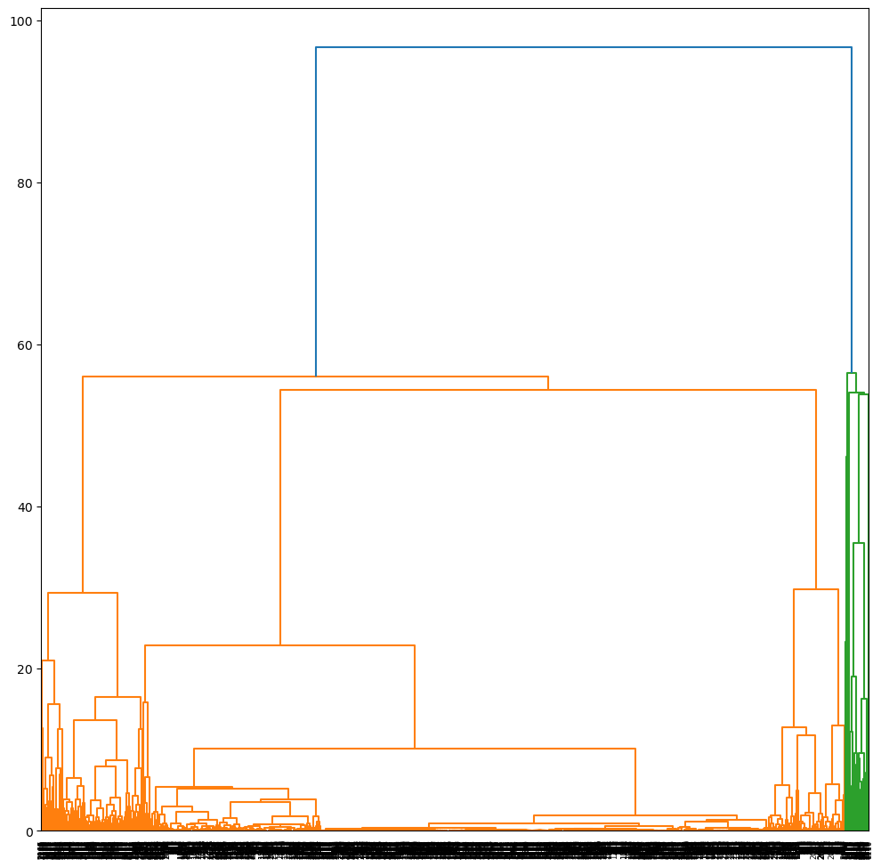

```python
# grouping data based on Ward distance
standard_mergings_ward = linkage(y = facebook_type_scaled,
                                 method = 'ward',
                                 optimal_ordering = True) # Arranges the clustered items

# setting plot size
fig, ax = plt.subplots(figsize=(12, 12)) # Defines the size of the figure

# developing a dendrogram
dendrogram(Z = standard_mergings_ward,
           leaf_rotation  = 90       , # Rotate the x-axis labels to 90 degrees for better readability.
           leaf_font_size = 6        ) # Set the font size for the x-axis labels to 6 for clarity.

# rendering the plot
plt.show()
```

Cluster Groupings: There are several distinct large clusters which indicate broad categories of Facebook content or interactions. These groupings are based on the similarity of scaled features in dataset.

Hierarchy of Relationships: Within the large clusters, there are smaller subclusters visible, indicating a hierarchy where some types of content or interactions are more closely related to each other than to those in different subclusters.

Cluster Density: Some areas of the dendrogram are very dense, implying that numerous types of content or interactions are quite similar to each other, while other areas are more spread out, suggesting greater dissimilarity.

Potential Outliers: The long vertical lines that connect at the higher distances may represent outliers or unique types of interactions/content that don't group well with others.

In summary, the dendrogram provides a visual map of how Facebook content or interactions can be grouped based on their similarity, which can be the basis for further detailed analysis and segmentation strategies.

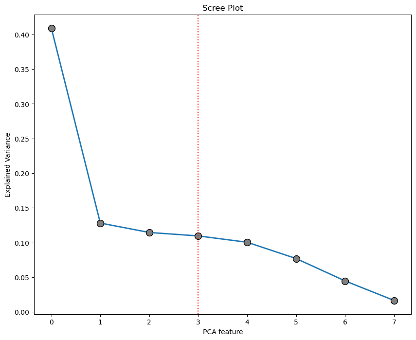

```python
# INSTANTIATING a PCA object with no limit to principal components
pca = PCA(n_components = None,
          random_state = 702)

# FITTING and TRANSFORMING the data
facebook_pca = pca.fit_transform(facebook_type_scaled)

# calling the scree_plot function
scree_plot(pca_object = pca)
```

### The second dot (PC 1: 0.125)

Moving to PC1, which accounts for around 12.5% of the variance, it represents a substantial but comparatively smaller portion of the dataset's variability. Despite this, PC1 still captures meaningful patterns that differ from those captured by PC0, providing additional insights into the dataset's structure. By examining the loading scores of variables on PC1, one can identify the specific aspects of the data that contribute most to this component's variance. This analysis can help uncover secondary patterns or trends that are distinct from those identified by PC0, enriching the overall understanding of the dataset.

### The third dot (PC 2: 0.12)

Finally, PC2, with an explained variance of approximately 12%, contributes further to understanding the dataset's structure by capturing additional patterns not fully represented by PC0 and PC1. While PC2 explains less variance than PC0 and PC1, its insights are still valuable for gaining a comprehensive understanding of the dataset's underlying characteristics. By exploring the relationship between variables and PC2, I can uncover unique features or relationships that contribute to the dataset's information. Thus, collectively analyzing PC0, PC1, and PC2 allows for a better understanding of the dataset's variability and underlying structure.

```python
# INSTANTIATING a new model using the first three principal components
pca_3 = PCA(n_components = 3,
            random_state = 702)

# FITTING and TRANSFORMING the data
facebook_pca_3 = pca_3.fit_transform(facebook_type_scaled)
```

```python
# transposing pca components (pc = MAX)
factor_loadings = pd.DataFrame(np.transpose(pca.components_))

# naming rows as original features
factor_loadings = factor_loadings.set_index(facebook_type_scaled.columns)

##################
### 3 PC Model ###
##################
# transposing pca components (pc = 3)
factor_loadings_3 = pd.DataFrame(np.transpose(pca_3.components_))

# naming rows as original features
factor_loadings_3 = factor_loadings_3.set_index(facebook_type_scaled.columns)

# checking the results
print(f"""
MAX Components Factor Loadings
------------------------------
{factor_loadings.round(2)}


3 Components Factor Loadings
------------------------------
{factor_loadings_3.round(2)}
""")
```

```
MAX Components Factor Loadings
------------------------------
                 0     1     2     3     4     5     6     7
num_comments  0.41 -0.31 -0.03 -0.20 -0.39 -0.18  0.67 -0.24
num_shares    0.49 -0.12  0.05 -0.17 -0.21 -0.22 -0.33  0.71
num_likes     0.16  0.73 -0.35  0.25 -0.49  0.11  0.05  0.00
num_loves     0.50  0.00  0.06 -0.08  0.01 -0.06 -0.56 -0.65
num_wows      0.30  0.48  0.08 -0.08  0.64 -0.42  0.29  0.04
num_hahas     0.37  0.01 -0.05 -0.20  0.28  0.84  0.14  0.12
num_sads      0.20 -0.35 -0.68  0.54  0.27 -0.09 -0.01  0.03
num_angrys    0.22 -0.04  0.63  0.72 -0.04  0.11  0.11  0.04


3 Components Factor Loadings
------------------------------
                 0     1     2
num_comments  0.41 -0.31 -0.03
num_shares    0.49 -0.12  0.05
num_likes     0.16  0.73 -0.35
num_loves     0.50  0.00  0.06
num_wows      0.30  0.48  0.08
num_hahas     0.37  0.01 -0.05
num_sads      0.20 -0.35 -0.68
num_angrys    0.22 -0.04  0.63
```

```python
# naming each principal component
factor_loadings_3.columns = ['User Engagement',
                             'Content Appeal & Acceptance',
                             'User Discontent']

# checking the result
factor_loadings_3.round(decimals = 2)
```

|  | User Engagement | Content Appeal & Acceptance | User Discontent |
| --- | --- | --- | --- |
| num_comments | 0.41 | -0.31 | -0.03 |
| num_shares | 0.49 | -0.12 | 0.05 |
| num_likes | 0.16 | 0.73 | -0.35 |
| num_loves | 0.50 | 0.00 | 0.06 |
| num_wows | 0.30 | 0.48 | 0.08 |
| num_hahas | 0.37 | 0.01 | -0.05 |
| num_sads | 0.20 | -0.35 | -0.68 |
| num_angrys | 0.22 | -0.04 | 0.63 |

INTERPRETATION 0 In this principal component analysis, the most significant features are num_loves (0.50), num_shares (0.49), and num_comments (0.41), all of which show strong positive loadings on PC0. This suggests that PC0 shows a dimension of social media interaction primarily driven by user engagement and positive feedback. A high score on PC0 could imply content that is not only commonly shared and liked but also evokes a strong connection with the audience, leading to a greater number of comments and 'love' reactions. The content that aligns with this component is likely to be uplifting or compelling, prompting a shared sense of community or appreciation among users.

INTERPRETATION 1 PC1 is characterized by a high positive loading on num_likes (0.73) and num_wows (0.48), indicating that this component represents the general appeal or acceptance of content among the audience. The high positive loadings on num_likes (0.73) and num_wows (0.48) likely show content that is widely appreciated and often elicits a reaction of amazement or impressive acknowledgment from viewers. The strong correlation with num_likes suggests a broad approval of the content, indicating that the audience likes the content. On the other hand, the num_wows implies that such content also has the capacity to surprise or exceed expectations, leading to higher engagement.

INTERPRETATION 2 The final component, PC2, the important feature is num_angrys (0.63) with a strong positive loading. This indicates that it captures the social media content that triggers user discontent. This component might be representative of provocative content that divides viewers and elicits a strong emotional reaction, particularly one of annoyance or frustration. This suggests that the content is likely causing a stir and provoking a negative response. It reflects the kind of posts that spark a heated reaction and get people fired up.

```python
# analyzing factor strengths per reaction
factor_loadings = pca_3.transform(facebook_type_scaled)

# converting to a DataFrame
factor_loadings_df = pd.DataFrame(factor_loadings)

# renaming columns
factor_loadings_df.columns = factor_loadings_3.columns

# checking the results
factor_loadings_df.head(n = 5)
```

|  | User Engagement | Content Appeal & Acceptance | User Discontent |
| --- | --- | --- | --- |
| 0 | -0.619670 | -0.006476 | 0.031211 |
| 1 | -0.469623 | 0.126667 | 0.013848 |
| 2 | -0.469004 | 0.125796 | 0.015559 |
| 3 | 0.367677 | 0.240069 | -0.089732 |
| 4 | -0.019679 | -0.278149 | -0.276109 |

```python
# converting reaction-level data into DataFrame
facebook_pca_3 = pd.DataFrame(facebook_pca_3)

# renaming reaction-level data
facebook_pca_3.columns = list(factor_loadings_3.columns)

# checking factor loadings per reaction
facebook_pca_3.head(n = 5)
```

|  | User Engagement | Content Appeal & Acceptance | User Discontent |
| --- | --- | --- | --- |
| 0 | -0.619670 | -0.006476 | 0.031211 |
| 1 | -0.469623 | 0.126667 | 0.013848 |
| 2 | -0.469004 | 0.125796 | 0.015559 |
| 3 | 0.367677 | 0.240069 | -0.089732 |
| 4 | -0.019679 | -0.278149 | -0.276109 |

```python
# checking variance amongst clusters
np.var(factor_loadings_df)
```

```
User Engagement                3.273609
Content Appeal & Acceptance    1.025052
User Discontent                0.916344
dtype: float64
```

```python
# applying the unsupervised_scaler function
pca_facebook_rescaled = scaler(df = factor_loadings_df)

# checking pre- and post-scaling variance
print(np.var(factor_loadings_df), '\n\n')
print(np.var(pca_facebook_rescaled))
```

```
User Engagement                3.273609
Content Appeal & Acceptance    1.025052
User Discontent                0.916344
dtype: float64


User Engagement                1.0
Content Appeal & Acceptance    1.0
User Discontent                1.0
dtype: float64
```

# Question 4: Segmentation with k-means clustering

```python
# INSTANTIATING a k-Means object with clusters
facebook_k_pca = KMeans(n_clusters   = 3     ,
                         n_init       = 'auto',
                         random_state = 702   )

# fitting the object to the data
facebook_k_pca.fit(pca_facebook_rescaled)

# converting the clusters to a DataFrame
facebook_kmeans_pca = pd.DataFrame({'Cluster': facebook_k_pca.labels_})

# checking the results
print(facebook_kmeans_pca.iloc[: , 0].value_counts())
```

```
0    2205
2     150
1       7
Name: Cluster, dtype: int64
```

## Cluster 0

Contains 2,205 data points. This is by far the largest cluster, suggesting that the majority of the data points share a set of characteristics that are similar to each other according to the clustering algorithm's criteria. Since this cluster has the majority of data points, the attributes defining this cluster could be seen as representative of the dataset's overall trends or the most common shared features among the data points analyzed.

## Cluster 1

Contains 7 data points, which makes it the smallest cluster among the three. This cluster may represent a more distinct or less common set of characteristics in the data compared to the other two. Being the least populous cluster, it implies that the data points within it share a set of characteristics that are even less common or more unique within the dataset. This cluster may highlight specific or rare conditions, behaviors, or features present in the data that are not as prevalent as those found in the larger clusters.

Therefore, the variation in cluster sizes helps in understanding the diversity of the data. Larger clusters may point to widespread trends, while smaller ones can indicate unique or specific patterns that may require separate analysis.

```python
# storing cluster centers
facebook_centroids_pca = facebook_k_pca.cluster_centers_

# converting cluster centers into a DataFrame
facebook_centroids_pca_df = pd.DataFrame(facebook_centroids_pca).round(decimals = 2)

# renaming principal components
facebook_centroids_pca_df.columns = ['User Engagement',
                                     'Content Appeal & Acceptance',
                                     'User Discontent']

# checking results (clusters = rows, pc = columns)
facebook_centroids_pca_df
```

|  | User Engagement | Content Appeal & Acceptance | User Discontent |
| --- | --- | --- | --- |
| 0 | -0.08 | -0.17 | 0.10 |
| 1 | 4.47 | -5.17 | -10.45 |
| 2 | 0.95 | 2.78 | -0.94 |

## Segment 0:

User Engagement: Negligible at -0.08.  
Content Appeal & Acceptance: Negligible at -0.17.  
User Discontent: Low but positive at 0.10.

This segment represents posts with negligible user engagement and content appeal. Despite the low overall activity, there's a slightly positive discontent score, which could imply a small number of users were not satisfied. An example of a "normal" post in this segment might be content that is largely ignored or not seen by users, with very few interactions and a minimal amount of dissatisfaction shown by the few who engage with it.

## Segment 2:

User Engagement: Moderate at 0.95.  
Content Appeal & Acceptance: Moderate at 2.78.  
User Discontent: Low at -0.94.

This segment represents posts with moderate user engagement and content appeal and acceptance, accompanied by low user discontent. A "normal" post in this segment could be engaging visual content or updates that resonate fairly well with the audience, leading to a reasonable level of interaction and positive sentiment, such as an interesting infographic or an enjoyable video clip. The engagement metrics might show a solid number of interactions with more positive than negative feedback.

```python
# concatenating cluster memberships with principal components
facebook_clst_pca_df = pd.concat([facebook_kmeans_pca,
                         factor_loadings_df],
                         axis = 1)

# concatenating other variables with pca-clusters
facebook_final_df = pd.concat([facebook_df.loc[ : , ['status_id', 'status_type', 'time_published']],
                               facebook_clst_pca_df.round(decimals = 2)],
                               axis = 1)

# renaming columns
facebook_final_df.columns = ['status_id',
                             'status_type',
                             'time_published',
                             'Cluster',
                             'User Engagement',
                             'Content Appeal & Acceptance',
                             'User Discontent']

# checking the results
facebook_final_df.head(5)
```

|  | status_id | status_type | time_published | Cluster | User Engagement | Content Appeal & Acceptance | User Discontent |
| --- | --- | --- | --- | --- | --- | --- | --- |
| 0 | 1 | photo | 2023-07-04 22:45:00 | 0 | -0.62 | -0.01 | 0.03 |
| 1 | 2 | photo | 2023-06-23 01:01:00 | 0 | -0.47 | 0.13 | 0.01 |
| 2 | 3 | photo | 2023-06-21 02:23:00 | 0 | -0.47 | 0.13 | 0.02 |
| 3 | 4 | video | 2023-06-14 05:16:00 | 0 | 0.37 | 0.24 | -0.09 |
| 4 | 5 | video | 2023-06-08 08:28:00 | 0 | -0.02 | -0.28 | -0.28 |

# Question 5: Logistic Regression

```python
# Convert the 'status_type' column to binary: 1 if 'photo', 0 for all other types.
facebook_df['status_type'] = facebook_df['status_type'].apply(lambda x: 1 if x == 'photo' else 0)

# Display the first 5 rows of the dataframe to verify the changes.
facebook_df.head(5)
```

|  | status_id | status_type | time_published | num_comments | num_shares | num_likes | num_loves | num_wows | num_hahas | num_sads | num_angrys |
| --- | --- | --- | --- | --- | --- | --- | --- | --- | --- | --- | --- |
| 0 | 1 | 1 | 2023-07-04 22:45:00 | 0 | 0 | 150 | 0 | 0 | 0 | 0 | 0 |
| 1 | 2 | 1 | 2023-06-23 01:01:00 | 2 | 3 | 202 | 7 | 1 | 0 | 0 | 0 |
| 2 | 3 | 1 | 2023-06-21 02:23:00 | 4 | 0 | 200 | 8 | 1 | 0 | 0 | 0 |
| 3 | 4 | 0 | 2023-06-14 05:16:00 | 100 | 30 | 303 | 23 | 1 | 5 | 0 | 0 |
| 4 | 5 | 0 | 2023-06-08 08:28:00 | 173 | 47 | 132 | 16 | 1 | 0 | 1 | 0 |

```python
#Checking the column
facebook_df.loc[ : ,'status_type'].value_counts(normalize = True).round(decimals = 2)
```

```
1    0.61
0    0.39
Name: status_type, dtype: float64
```

## Model 1

```python
# Define a list of feature names to be used for modeling
model1_features = ['num_comments',
                   'num_shares',
                   'num_likes',
                   'num_loves',
                   'num_wows',
                   'num_hahas',
                   'num_sads',
                   'num_angrys']

# Select the target variable for the model
y_model1 = facebook_df['status_type']
```

```python
# Correcting the dependent variable to be binary
y_model1 = facebook_df['status_type']

# Perform train-test split using only the selected features for X
x_train, x_test, y_train, y_test = train_test_split(
            facebook_df[model1_features],  # Use only the features in model1_features
            y_model1,                      # Target variable
            test_size=0.25,                # 25% of the data is allocated to the test set
            random_state=219,              # Seed for the random number generator for reproducibility
            stratify=y_model1)             # Preserving balance

# Merging training data for statsmodels
facebook_train = pd.concat([x_train, y_train], axis=1)

# Constructing the formula for logistic regression model
features_formula = ' + '.join(model1_features)  # Concatenates all feature names, separated by '+'
formula = f'status_type ~ {features_formula}'   # Constructs the formula as 'target ~ features'

# Instantiating and fitting the logistic regression model
logistic_model = smf.logit(formula=formula, data=facebook_train)
results = logistic_model.fit()

# Displaying the summary of the model
print(results.summary2())
```

```
Optimization terminated successfully.
         Current function value: 0.519371
         Iterations 10
                          Results: Logit
==================================================================
Model:              Logit            Method:           MLE
Dependent Variable: status_type      Pseudo R-squared: 0.223
Date:               2024-04-14 15:42 AIC:              1857.6121
No. Observations:   1771             BIC:              1906.9258
Df Model:           8                Log-Likelihood:   -919.81
Df Residuals:       1762             LL-Null:          -1183.6
Converged:          1.0000           LLR p-value:      8.4943e-109
No. Iterations:     10.0000          Scale:            1.0000
-------------------------------------------------------------------
                Coef.   Std.Err.     z     P>|z|    [0.025   0.975]
-------------------------------------------------------------------
Intercept       1.0775    0.0652  16.5172  0.0000   0.9497   1.2054
num_comments   -0.0047    0.0011  -4.3979  0.0000  -0.0068  -0.0026
num_shares     -0.0027    0.0024  -1.1234  0.2613  -0.0074   0.0020
num_likes      -0.0004    0.0001  -3.7446  0.0002  -0.0006  -0.0002
num_loves      -0.0383    0.0116  -3.2933  0.0010  -0.0612  -0.0155
num_wows        0.0532    0.0093   5.7480  0.0000   0.0350   0.0713
num_hahas      -0.0192    0.0197  -0.9739  0.3301  -0.0578   0.0194
num_sads        0.0639    0.0672   0.9504  0.3419  -0.0678   0.1956
num_angrys      0.0890    0.1429   0.6227  0.5335  -0.1911   0.3690
==================================================================
```

## Model 2

```python
# Define a list of feature names to be used for modeling
model2_features = ['num_comments',
                   'num_shares',
                   'num_likes',
                   'num_loves',
                   'num_wows',
                   'num_angrys']

# Select the target variable for the model
y_model2 = facebook_df['status_type']
```

```python
# Correcting the dependent variable to be binary
y_model2 = facebook_df['status_type']

# Perform train-test split using only the selected features for X
x_train, x_test, y_train, y_test = train_test_split(
            facebook_df[model2_features],  # Use only the features in model2_features
            y_model2,                      # Target variable
            test_size=0.25,                # 25% of the data is allocated to the test set
            random_state=219,              # Seed for the random number generator for reproducibility
            stratify=y_model2)             # Preserving balance

# Merging training data for statsmodels
facebook_train = pd.concat([x_train, y_train], axis=1)

# Constructing the formula for logistic regression model
features_formula = ' + '.join(model2_features)  # Concatenates all feature names, separated by '+'
formula = f'status_type ~ {features_formula}'   # Constructs the formula as 'target ~ features'

# Instantiating and fitting the logistic regression model
logistic_model2 = smf.logit(formula=formula, data=facebook_train)
results = logistic_model2.fit()

# Displaying the summary of the model
print(results.summary2())
```

```
Optimization terminated successfully.
         Current function value: 0.520069
         Iterations 10
                          Results: Logit
==================================================================
Model:              Logit            Method:           MLE
Dependent Variable: status_type      Pseudo R-squared: 0.222
Date:               2024-04-14 15:42 AIC:              1856.0860
No. Observations:   1771             BIC:              1894.4411
Df Model:           6                Log-Likelihood:   -921.04
Df Residuals:       1764             LL-Null:          -1183.6
Converged:          1.0000           LLR p-value:      3.2845e-110
No. Iterations:     10.0000          Scale:            1.0000
-------------------------------------------------------------------
                Coef.   Std.Err.     z     P>|z|    [0.025   0.975]
-------------------------------------------------------------------
Intercept       1.0807    0.0650  16.6298  0.0000   0.9533   1.2081
num_comments   -0.0047    0.0011  -4.4074  0.0000  -0.0068  -0.0026
num_shares     -0.0027    0.0025  -1.0937  0.2741  -0.0076   0.0022
num_likes      -0.0004    0.0001  -3.7400  0.0002  -0.0006  -0.0002
num_loves      -0.0381    0.0115  -3.3050  0.0009  -0.0607  -0.0155
num_wows        0.0523    0.0092   5.6634  0.0000   0.0342   0.0704
num_angrys      0.0940    0.1488   0.6318  0.5275  -0.1976   0.3857
==================================================================
```

# Model 3

```python
# Convert 'status_type' column to binary, 1 for 'photo' and 0 otherwise
facebook_final_df['status_type'] = facebook_final_df['status_type'].apply(lambda x: 1 if x == 'photo' else 0)

facebook_final_df.head(5)
```

|  | status_id | status_type | time_published | Cluster | User Engagement | Content Appeal & Acceptance | User Discontent |
| --- | --- | --- | --- | --- | --- | --- | --- |
| 0 | 1 | 1 | 2023-07-04 22:45:00 | 0 | -0.62 | -0.01 | 0.03 |
| 1 | 2 | 1 | 2023-06-23 01:01:00 | 0 | -0.47 | 0.13 | 0.01 |
| 2 | 3 | 1 | 2023-06-21 02:23:00 | 0 | -0.47 | 0.13 | 0.02 |
| 3 | 4 | 0 | 2023-06-14 05:16:00 | 0 | 0.37 | 0.24 | -0.09 |
| 4 | 5 | 0 | 2023-06-08 08:28:00 | 0 | -0.02 | -0.28 | -0.28 |

```python
# Define features for the model
model3_features = ['Cluster',
                   'User Engagement',
                   'Content Appeal & Acceptance',
                   'User Discontent']

# Perform train-test split
X = facebook_final_df[model3_features]         # Selecting features for X
y = facebook_final_df['status_type']           # Selecting target variable for y
X_train, X_test, y_train, y_test = train_test_split(X,                 # Splitting X
                                                    y,                 # Splitting y
                                                    test_size=0.25,    # 25% for testing
                                                    random_state=219,  # Random seed for reproducibility
                                                    stratify=y)        # Stratified split to preserve class distribution

# Merge training data for statsmodels
facebook_train = pd.concat([X_train, y_train], axis=1)

# Prepare the formula, correctly wrapping variable names with spaces in `Q()`
features_formula = ' + '.join([f'Q("{feature}")' if ' ' in feature else feature for feature in model3_features]) # Handling variable names with spaces
formula = 'status_type ~ ' + features_formula # Constructing formula for logistic regression

# Instantiate and fit the logistic regression model
logistic_model = smf.logit(formula=formula, data=facebook_train) # Creating logistic regression model
result = logistic_model.fit()

# Display the summary of the model
print(result.summary2())
```

```
Optimization terminated successfully.
         Current function value: 0.557857
         Iterations 8
                                 Results: Logit
=================================================================================
Model:                    Logit                 Method:                MLE
Dependent Variable:       status_type           Pseudo R-squared:      0.165
Date:                     2024-04-14 15:42      AIC:                   1985.9298
No. Observations:         1771                  BIC:                   2013.3263
Df Model:                 4                     Log-Likelihood:        -987.96
Df Residuals:             1766                  LL-Null:               -1183.6
Converged:                1.0000                LLR p-value:           2.1539e-83
No. Iterations:           8.0000                Scale:                 1.0000
---------------------------------------------------------------------------------
                                  Coef.  Std.Err.    z     P>|z|   [0.025  0.975]
---------------------------------------------------------------------------------
Intercept                         0.0702   0.0771   0.9106 0.3625 -0.0809  0.2214
Cluster                           0.4959   0.2227   2.2272 0.0259  0.0595  0.9323
Q("User Engagement")             -1.3550   0.1137 -11.9182 0.0000 -1.5778 -1.1321
Q("Content Appeal & Acceptance") -0.2109   0.1207  -1.7468 0.0807 -0.4476  0.0257
Q("User Discontent")             -0.0075   0.1241  -0.0603 0.9519 -0.2507  0.2358
=================================================================================
```

# Question 6: Best Model Selection

## Model 1:

Pseudo R-squared: 0.223 AIC: 1857.6121 BIC: 1906.9258 LLR p-value: 8.4943e-109

## Model 2:

Pseudo R-squared: 0.222 AIC: 1856.0860 BIC: 1894.4411 LLR p-value: 3.2845e-110

## Model 3:

Pseudo R-squared: 0.165 AIC: 1985.9298 BIC: 2013.3263 LLR p-value: 2.1539e-83

## Interpretation:

Based on these metrics, the best model is typically the one with the highest Pseudo R-squared (indicating a better fit), the lowest AIC and BIC (indicating a more parsimonious model), and the smallest LLR p-value (indicating the model is a significant improvement over the null model).

Model 1 and Model 2 are quite similar in terms of Pseudo R-squared, but Model 2 has a slightly lower AIC and BIC, which suggests it is a more efficient model. Model 3 has the lowest Pseudo R-squared and the highest AIC and BIC, indicating it might not fit the data as well as the other models.

```python
# Perform train-test split using the selected features for X
X = facebook_df[model2_features]
y = facebook_df['status_type']

x_train, x_test, y_train, y_test = train_test_split(
    X,
    y,
    test_size=0.25,
    random_state=219,
    stratify=y)  # Make sure to stratify by y to preserve class balance

# Instantiate the logistic regression model
logreg = LogisticRegression(solver='lbfgs', max_iter=200, random_state=219)

# Fit the model on training data
logreg_fit = logreg.fit(x_train, y_train)  # Fitting the model to the training data

# Predict and evaluate the model
y_pred_train = logreg_fit.predict(x_train) # Predicting on training data
y_pred_test = logreg_fit.predict(x_test)   # Predicting on testing data

train_accuracy = accuracy_score(y_train, y_pred_train) # Calculating training accuracy
test_accuracy = accuracy_score(y_test, y_pred_test)    # Calculating testing accuracy
train_test_gap = abs(train_accuracy - test_accuracy)   # Calculating the absolute difference between training and testing accuracy

# Print model evaluation results
print(f"Training ACCURACY: {train_accuracy:.4f}") # Printing training accuracy
print(f"Testing ACCURACY: {test_accuracy:.4f}")   # Printing testing accuracy
print(f"Train-Test Gap: {train_test_gap:.4f}")    # Printing train-test gap
```

```
Training ACCURACY: 0.7516
Testing ACCURACY: 0.7360
Train-Test Gap: 0.0155
```

```python
from sklearn.metrics import roc_auc_score, precision_score, recall_score

# Get the predicted probabilities for the positive class
y_score = logreg_fit.predict_proba(x_test)[:, 1]  # Probabilities for the positive class

# Calculate AUC
auc = round(roc_auc_score(y_true=y_test, y_score=y_score), ndigits=4)

# Calculate precision and recall using the predictions
precision = round(precision_score(y_true=y_test, y_pred=y_pred_test), ndigits=4)
recall = round(recall_score(y_true=y_test, y_pred=y_pred_test), ndigits=4)

# Print the results
print(f"AUC: {auc}")
print(f"Precision: {precision}")
print(f"Recall: {recall}")
```

```
AUC: 0.6684
Precision: 0.7122
Recall: 0.9529
```

## Confusion matrix

```python
# creating a confusion matrix
print(confusion_matrix(y_true = y_test,
                       y_pred = y_pred_test))
```

```
[[ 91 139]
 [ 17 344]]
```

```python
from sklearn.metrics import confusion_matrix

# Predicting using the test data
logreg_pred = logreg_fit.predict(x_test)

# Calculating the confusion matrix
logreg_tn, logreg_fp, logreg_fn, logreg_tp = confusion_matrix(y_true=y_test, y_pred=logreg_pred).ravel()

# Printing each result one-by-one
print(f"""
True Negatives : {logreg_tn}
False Positives: {logreg_fp}
False Negatives: {logreg_fn}
True Positives : {logreg_tp}
""")
```

```
True Negatives : 91
False Positives: 139
False Negatives: 17
True Positives : 344
```

[figure not shown]

```python
## Visualized Confusion Matrix
# calling the visual_cm function
visual_cm(true_y = y_test,
          pred_y = y_pred_test,
          labels = ['photo', 'not photo'])
```

The confusion matrix for the classifier provides a visualization of the performance of the logistic regression model for the binary classification task—distinguishing between 'photo' and 'not photo' classes.

True Positives (TP): 344 - These are the cases where the model correctly predicts 'photo'. This accuracy is beneficial for the business, as it ensures that photos are correctly identified, possibly for targeting photo-related features or ads.

True Negatives (TN): 91 - These are the cases where the model correctly predicts 'not photo'. For a business, this means that non-photo content is accurately recognized, allowing for appropriate content management and strategy development.

False Positives (FP): 139 - These are the cases where the model incorrectly predicts 'not photo' as 'photo'. This type of error could lead to inappropriate content recommendations or misallocation of resources toward content that doesn't engage the audience as expected.

False Negatives (FN): 17 - These are the cases where the model incorrectly predicts 'photo' as 'not photo'. This error is potentially more harmful because it could result in missed opportunities to capitalize on photo engagement. Photos that might have been more engaging or might have required moderation are overlooked, possibly affecting user experience and engagement metrics.